# Paired T-Test Practice

# Instructions

Here are several opportunities to practice analyzing dependent samples using R. For each question, you will:

- Read in data
- Create data summaries (numerical and graphical)
- Statistically analyze the data
- Check for the suitability of the statistical test (CLT, Normality)
- State your hypothesis test conclusions and interpret your confidence intervals

# Helmet Measurements

After purchasing a batch of flight helmets that did not fit the heads of many pilots, the NZ Airforce decided to measure the head sizes of all recruits. Before this was carried out, information was collected to determine the feasibility of using cheap cardboard calipers to make the measurements, instead of metal ones which were expensive and uncomfortable.

The data lists the head diameters of 18 recruits measured once using cardboard calipers and again using metal calipers. One question is whether there is *any* systematic difference between the two measurement tools.

**NOTE**: Define the difference as cardboard - metal.

Use $\alpha = 0.05$ significance level.

## Step 1: Load the Data

```r
library(tidyverse)
library(mosaic)
library(rio)
library(car)

helmet_fit <- import("https://byuistats.github.io/M221R/Data/quiz/R/helmet_fit.csv")
```

## Step 2: Explore the Data and Generate Hypotheses

Create histograms and summary statistic tables for the measurements for each type of tool:

```r
diff <- helmet_fit$cardboard - helmet_fit$metal
data <- helmet_fit %>% pivot_longer(cols = everything(), names_to = "Helmet", values_to = "Size")
aov_df <- aov(Size ~ Helmet, data = data)
summary(aov_df)
```

```
            Df Sum Sq Mean Sq F value Pr(>F)
Helmet       1   23.4   23.36   0.724  0.401
Residuals   34 1097.4   32.28
```

## Step 3: Prepare the data for analysis

**Question**: What does a negative number mean given the definition of the difference?  
**Answer**: the comparasion value(cardboard) is smaller to the mean compared(metal).

Create a `qqPlot()` of the differences:

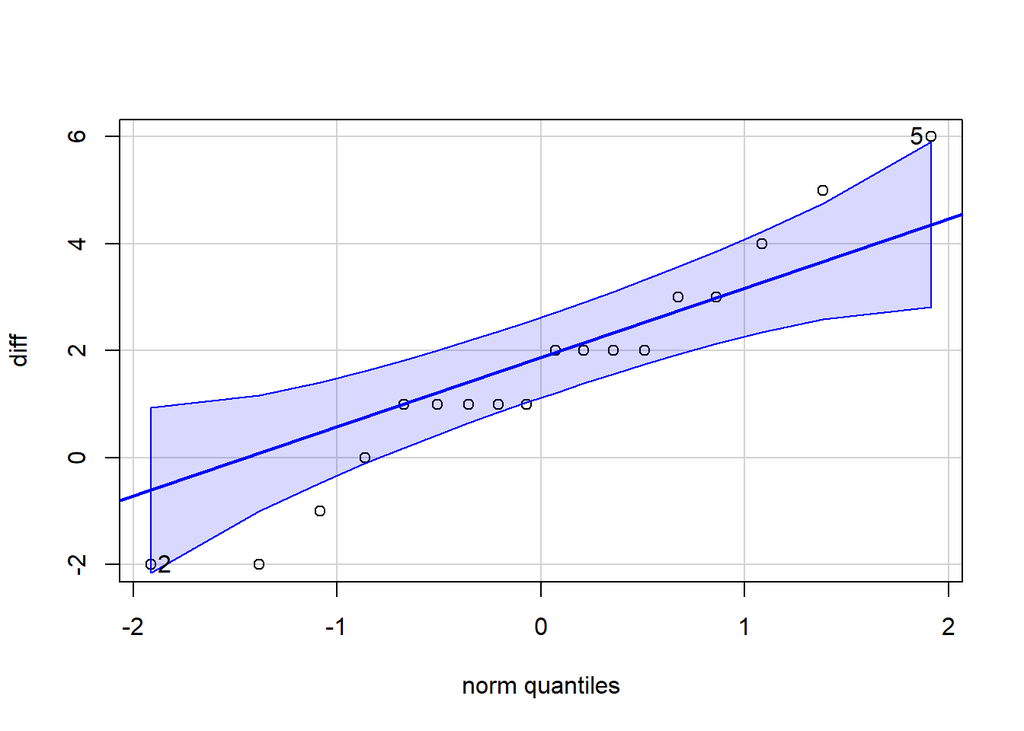

```
[1] 5 2
```

```r
qqPlot(diff)
```

## Step 4: Perform the Appropriate Analyses

### Hypothesis Test

Make the following null and alternative hypothesis correct by deleting what doesn’t belong:

$$H_0: \mu_d > < = \ 0$$

$$H_a: \mu_d > < = \ne 0$$

```r
t.test(diff)
```

```
    One Sample t-test

data:  diff
t = 3.1854, df = 17, p-value = 0.005415
alternative hypothesis: true mean is not equal to 0
95 percent confidence interval:
 0.5440163 2.6782060
sample estimates:
mean of x
 1.611111
```

**Question**: What is the value of the test statistic, $t$?  
**Answer**: 3.1854

**Question**: How many degrees of freedom does this test statistics have?  
**Answer**: 17

**Question**: What is the P-value?  
**Answer**: 0.005415

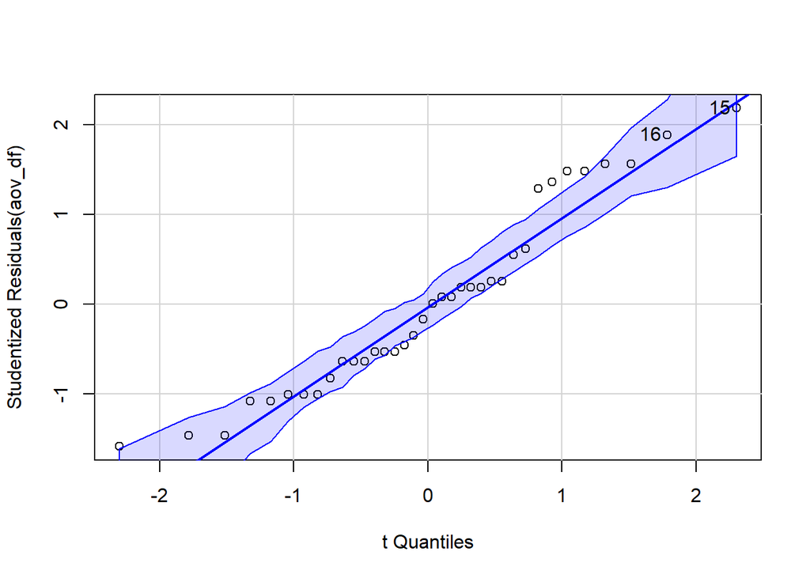

```
[1] 15 16
```

```r
qqPlot(aov_df)
```

**Question**: State your conclusion about the hypothesis test.  
**Answer**: The p-value is smaller than sigma, therefore rejecting the null and impliying there is an systematical difference between cardboard and metal healmets.

### Confidence Intervals

Create a 95% confidence interval for the true average difference between the cardboard and the metal measurement tools:

```r
t.test(diff, conf.level = .95)
```

```
    One Sample t-test

data:  diff
t = 3.1854, df = 17, p-value = 0.005415
alternative hypothesis: true mean is not equal to 0
95 percent confidence interval:
 0.5440163 2.6782060
sample estimates:
mean of x
 1.611111
```

**Question**: Give a one-sentence explanation of your confidence interval.  
**Answer**: I am 95% sure that the true average difference is between 0.5440163 and 2.6782060.

# Cholesterol

A study was conducted at a major northeastern American medical center regarding blood cholesterol levels and heart-attack incidents. A total of 28 heart-attack patients had their cholesterol levels measured two days after the heart attack and again four days after the heart attack. Researchers want to see if cholesterol levels reduced significantly four days after the attack versus two days after the attack.

Use the level of significance of 0.05.

## Step 1: Load the Data

```r
cholesterol <- import("https://byuistats.github.io/M221R/Data/quiz/R/cholesterol.csv")
chol_data <- cholesterol %>% pivot_longer(-patient, names_to = "Chol_day", values_to = "value")
```

## Step 2: Review the Data Generate Hypotheses

Create histograms and summary statistics tables for the cholesterol measurements at 2 days and at 4 days.

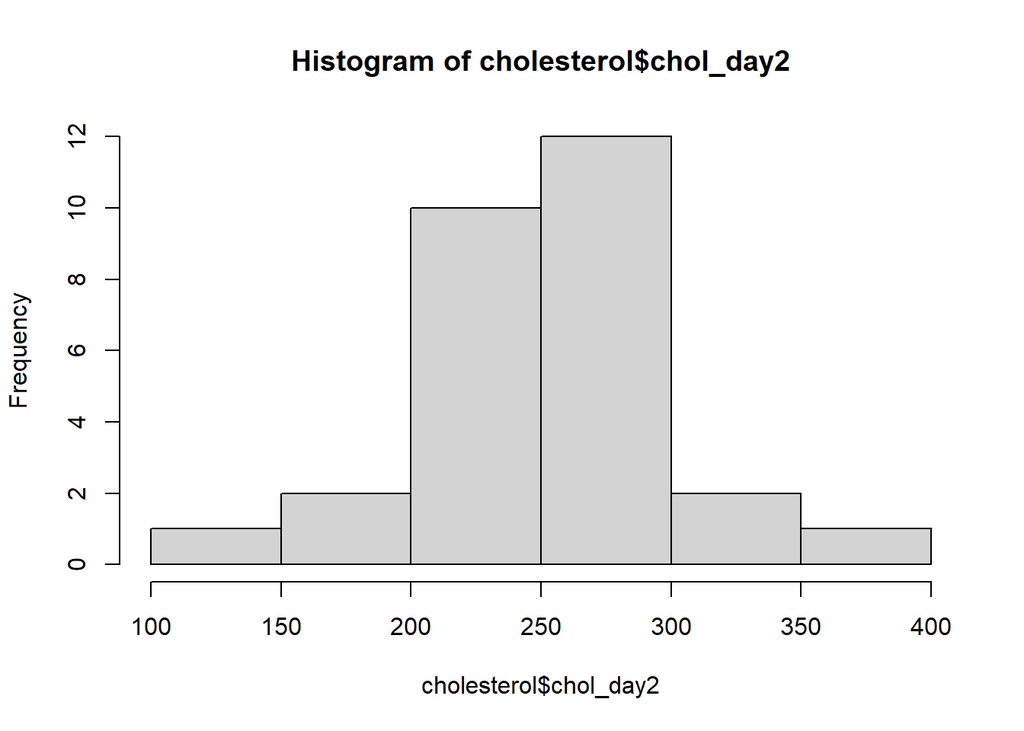

```r
hist(cholesterol$chol_day2)
```

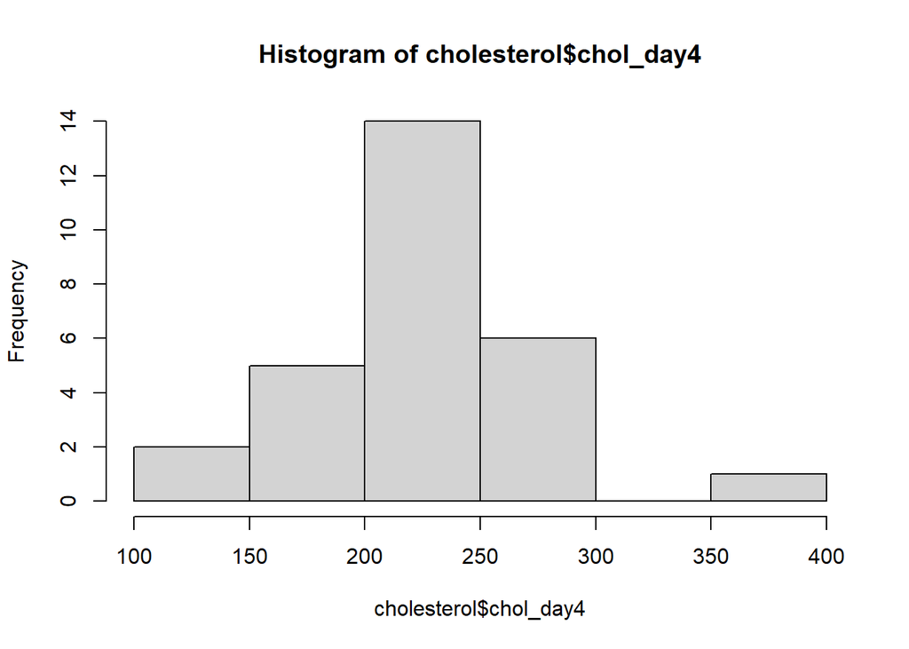

```r
hist(cholesterol$chol_day4)
```

```r
favstats(cholesterol$chol_day2)
```

```
 min    Q1 median  Q3 max     mean       sd  n missing
 142 225.5    268 282 360 253.9286 47.71049 28       0
```

```r
favstats(cholesterol$chol_day4)
```

```
 min    Q1 median    Q3 max     mean       sd  n missing
 116 201.5    235 250.5 352 230.6429 46.96745 28       0
```

## Step 3: Prepare the data for analysis

Decide how you are going to define the difference (chol_day2 - chol_day4 or chol_day4 - chol_day2).

What does a negative number mean:

What is your null and alternative hypotheses:

$$H_0: \mu_d > < = \ 0$$

$$H_a: \mu_d > < \ne 0$$

Create a `qqPlot()` of the differences and determine if you can trust the statistical tests.

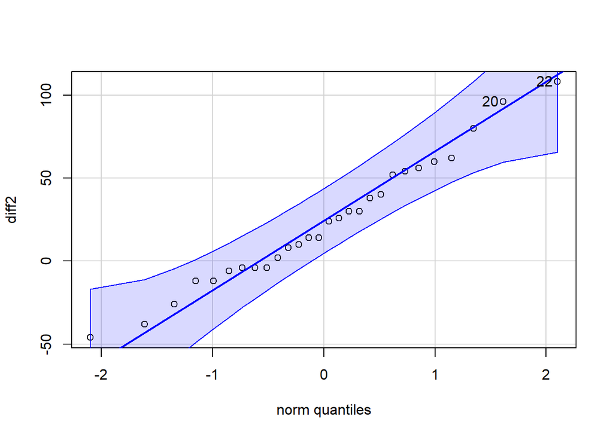

```
[1] 22 20
```

```r
diff2 <- cholesterol$chol_day2 - cholesterol$chol_day4
qqPlot(diff2)
```

## Step 4: Perform the appropriate analysis

### Hypothesis Test

Perform a t-test for the differences.

```r
t.test(diff2)
```

```
    One Sample t-test

data:  diff2
t = 3.2189, df = 27, p-value = 0.003337
alternative hypothesis: true mean is not equal to 0
95 percent confidence interval:
  8.442836 38.128593
sample estimates:
mean of x
 23.28571
```

**Question**: What is the value of the test statistic, $t$?  
**Answer**: 3.2189

**Question**: How many degrees of freedom does this test statistics have?  
**Answer**: 27

**Question**: What is the P-value?  
**Answer**: 0.003337

### Confidence Interval

Create a 95% confidence interval for the difference in cholesterol scores:

```r
t.test(diff2, conf.level = 0.95)
```

```
    One Sample t-test

data:  diff2
t = 3.2189, df = 27, p-value = 0.003337
alternative hypothesis: true mean is not equal to 0
95 percent confidence interval:
  8.442836 38.128593
sample estimates:
mean of x
 23.28571
```